# Elementary Statistics using Excel

Nov 27, 2018

## Chapter 7 Section 2 Objectives

### Estimating a Population Mean

- Construct a confidence interval estimate of a population mean, and be able to interpret such confidence interval.
- Determine the sample size necessary to estimate a population mean

## Estimating a population mean when \(\sigma\) is not known

- It is rare to estimate a a population mean (\(\mu\)) and also know the standard deviation (\(\sigma\)).
- The sample mean (\(\bar{x}\)) is the best point estimate of \(\mu\).
  - \(\bar{x}\) gives no clue to how accurate it is at estimating \(\mu\).
  - A confidence interval (CI) must be constructed to show accuracy.

## Requirements of a confidence interval for estimating \(\mu\) with \(\sigma\) not known

- The sample is a simple random sample.
- The sample meets one of the following:
  - The population is normally distributed.
  - The sample size (\(n\)) is greater than 30.

## Margin of Error

\[\Huge E = t_{\frac{\alpha}{2}}\cdot \frac{s}{\sqrt{n}}\]

- degrees of freedom (df) is \(n-1\).
- \(\alpha\) is 1 - confidence level.
- \(n\) is the sample size
- \(s\) is the sample standard deviation

## Confidence interval and the students t distribution

\[\Huge \bar{x} \pm E\]

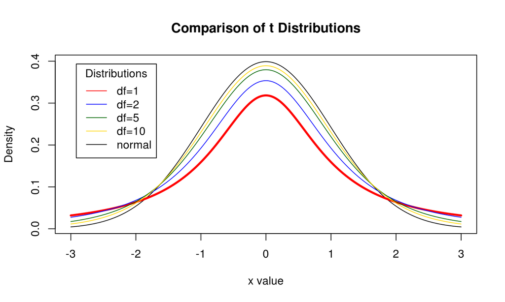

- \(t_{\frac{\alpha}{2}}\) = T.INV.T2(\(alpha\),df)
- remember df = \(n-1\) and \(\alpha\) = 1 - confidence level
- Given 15 data points:
  - 11,12,13,14,15,16,17,18,19,20,21,22,23,24,25
- Find the 95% confidence interval of the mean

## Interpreting the Confidence interval

- We are 95% confident that the interval of lower limit to upper limit contains the true population mean of \(\mu\).

## Determining sample size needed

\[\Huge n = (\frac{z_{\frac{\alpha}{2}}\cdot \sigma}{E})^2 \]

- \(E\) is the desired amount of error
- \(\sigma\) population standard deviation. Usually unknown
  - Range rule of thumb \(\frac{\textrm{range}}{4}\)
  - Use sample standard deviation
  - Use results from an earlier study

## Confidence interval when \(\sigma\) is known

\[\Huge E = z_\frac{\alpha}{2}\cdot\frac{\sigma}{\sqrt{n}}\]

- Use excel CONFIDENCE.NORM
  - \(E\) = CONFIDENCE.NORM(\(\alpha\),\(\sigma\), \(n\))
- CI = \(\bar{x} \pm E\)

## Chapter 7 Section 3 Objectives

### Estimating a Population Standard Deviation or Variance

- Develop the ability to construct a confidence interval estimate of a population standard deviation or variance, and be able to interpret such confidence interval estimates.

## Chi-Square Method of estimating variance

\[\large \chi^2 = \frac{(n-1)\cdot s^2}{\sigma^2}\]

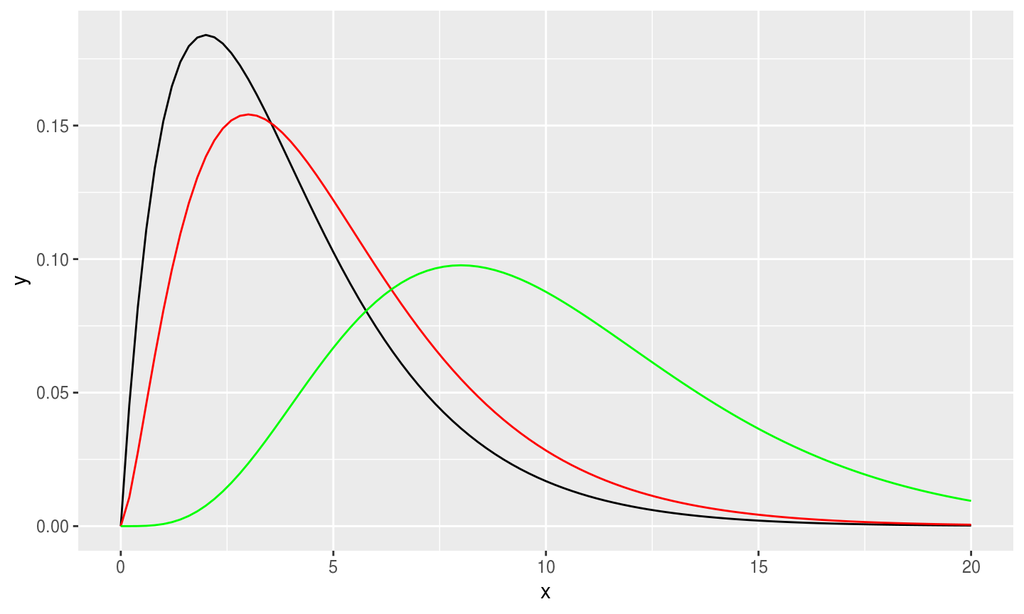

## Using excel to find a confidence interval

- Left and right are different so must be done separately
- CHISQ.INV (\(\chi^2_L\)) and CHISQ.INV.RT (\(\chi^2_R\))

\[\Huge (\frac{(n-1)\cdot s^2}{\chi^2_R},\frac{(n-1)\cdot s^2}{\chi^2_L})\]

\[\Huge ( \sqrt{\frac{(n-1)\cdot s^2}{\chi^2_R}}, \sqrt{\frac{(n-1)\cdot s^2}{\chi^2_L}})\]

## For determining sample size of \(\chi^2\) distribution

- This is very complex due to the distribution not being normal
- Refer to table 7-2 on page 365 of your book.